# ボクセルの木化

ryamada

2018年5月13日

# 形上の距離情報を持った木を作って図示してみて考える

## 作戦

- S2同相な形がセグメンテーションされたボクセル集合となっているとする。
- ボクセルの表面は正方形でできている(長方形でできている場合には、適当に分割することにする)ので、ボクセル表面は単位正方形による四角化グラフである。これは平面グラフである。
- この平面四角化グラフは、あるルールによりラベル付きの木と１対１対応する。
- そのルールとは以下の通りである。
- １つのノードをルートとして取る。
- そのノードからのグラフ距離を計算する。グラフ距離をそのノードのラベル値とする。
- 各正方形にある４頂点のラベル値のつき方から、１辺を取り出すか、１対角線を取り出すことにする。
- この結果、ルートノード以外のすべてのノードをスパンする木が構成されることが知られている。
- さらに、この木は任意の２ノード間のグラフ距離に関する情報を以下のように保持していることも知られている。
- 元の四角化グラフが平面グラフであるので、木グラフもエッジが重ならないように平面に置かれている。この木グラフのすべてのエッジを往復することにすると、時計回り・反時計回りにぐるりと一周することができる。木グラフの置かれ方に注意して、きちんと一周するようにする。回り方はどちらかに固定することとする。
- 今、２頂点 x, y間のパスは、xからyへと辿るか、yからxへ辿るかの２つある。今、x,yのラベル値がv(x),v(y)であって、それぞれのパス上のノードのラベル値の最小値が vm(x->y), vm(y->x)であったとき、２頂点間のグラフ距離は、v(x)+v(y) - 2 max(vm(x->y),vm(y->x)) +2 以下であることが知られている。
- またグラフ間距離は不等式であるが、これの極限では等式が成り立つことも知られている。
- この木の周回を円周として表すこととして、木の上で対応する点同士が見てわかるように描くこととする。
- また、ノードのラベル値はノード間グラフ距離としてどちらの辿り方を採用するべきかの情報なので、ノードのラベル値で色分けをすることにする。

## 諸関数

```r
library(rgl)
```

```r
library(igraph)
library(stringr)
# 単位立方体の面を列挙する
my.vox.faces <- function(xyz){
    rbind(c(xyz,1),c(xyz,2),c(xyz,3),c(xyz+c(1,0,0),2),c(xyz+c(0,1,0),3),c(xyz+c(0,0,1),1))
}

# 単位面の頂点を列挙する
my.face.nodes <- function(xyzw){
    xyz <- xyzw[1:3]
    w <- xyzw[4]
    if(w==1){
        ret <- rbind(xyz,xyz+c(1,0,0),xyz+c(0,1,0),xyz+c(1,1,0))
    }else if(w==2){
        ret <- rbind(xyz,xyz+c(0,1,0),xyz+c(0,0,1),xyz+c(0,1,1))
    }else{
        ret <- rbind(xyz,xyz+c(0,0,1),xyz+c(1,0,0),xyz+c(1,0,1))
    }
    return(ret)
}

# ボクセル集合の表面を形成する面を抽出する
# x は行列
# 返り値はリストで、リストの第１要素は、同一行がない行か否かのboolean ベクトル
# リストの第２要素は、同一行がない行を抽出した行列
my.onlyone <- function(x){
    n <- length(x[,1])
    a <- !duplicated(x)
    b <- !duplicated(x[n:1,])[n:1]

    return(list(a & b,x[a & b,]))
}
my.vox.surface <- function(Vlist){
    faces <- matrix(0,0,4)

    for(i in 1:length(Vlist[,1])){
        faces <- rbind(faces,my.vox.faces(Vlist[i,]))

    }
    omoteura <- rep(c(0,0,0,1,1,1),length(faces[,1]))
    onlyones <- my.onlyone(faces)
    #print(onlyones[[1]])
    return(list(onlyones[[2]],omoteura[which(onlyones[[1]])]))
}

# 表面頂点リストを作る
my.surface.nodes <- function(faces){
    vs <- matrix(0,0,3)
    for(i in 1:length(faces[,1])){
        vs <- rbind(vs,my.face.nodes(faces[i,]))
    }
    return(unique(vs))
}

# 表面正方形リストから表面四角メッシュのエッジリストを作る
my.surface.graph <- function(face.nodes){
  el <- matrix(0,0,2)
  for(i in 1:length(face.nodes[,1])){
    tmp <- face.nodes[i,]
    el <- rbind(el,tmp[1:2],tmp[2:3],tmp[3:4],tmp[c(4,1)])
  }
    el <- t(apply(el,1,sort))
    el <- unique(el)
    el
}

# 単位正方形の４頂点をその順序に注意して取り出す。

my.face.nodesid <- function(faces,faces.omoteura,nodes){
    ret <- matrix(0,length(faces[,1]),4)
    for(i in 1:length(faces[,1])){
        nodes.xyz <- my.face.nodes(faces[i,])
        nodes.xyz <- nodes.xyz[c(1,2,4,3),] # 反時計回り
        if(faces[i,4]==1){
            if(faces.omoteura[i]==0){
                #nodes.xyz <- nodes.xyz[c(1,4,3,2),]
            }else{
                nodes.xyz <- nodes.xyz[c(1,4,3,2),]
            }
        }else if(faces[i,4]==2){
            if(faces.omoteura[i]==0){
                #nodes.xyz <- nodes.xyz[c(1,4,3,2),]
            }else{
                nodes.xyz <- nodes.xyz[c(1,4,3,2),]
            }
        }else{
            if(faces.omoteura[i]==0){
                #nodes.xyz <- nodes.xyz[c(1,4,3,2),]
            }else{
                nodes.xyz <- nodes.xyz[c(1,4,3,2),]
            }
        }
        nodes.id <- rep(0,4)
        for(j in 1:4){
            tmp <- t(nodes) - nodes.xyz[j,]
            tmp2 <- apply(tmp^2,2,sum)
            nodes.id[j] <- which(tmp2==0)
            ret[i,] <- nodes.id
        }
    }
    return(ret)
}

# 四角化グラフから木を作る
my.tree.edge <- function(vals){ # 反時計回り
    tmp <- which(vals == max(vals))
    if(length(tmp)==2){
        ret <- tmp
        #print("diagonal")
    }else{
        ret <- c(tmp,tmp+1)
        if(ret[2] > 4){
            ret[2] <- 1
        }
    }
    return(ret)
}

my.select.face.edge <- function(nodeid,rootdist){
    vals <- rootdist[nodeid]
    tmp <- my.tree.edge(vals)
    return(nodeid[tmp])
}

my.tree.edges <- function(face.nodes,rootdist){
    tmp <- apply(face.nodes,1,my.select.face.edge,rootdist)
    ret <- matrix(tmp,nrow=2)
    return(t(ret))
}

# 描図する

my.draw.surface <- function(nodes,root,edges,tree.edges=Null,axes = FALSE,radius.root = 0.1){
    plot3d(nodes,axes=axes,xlab="x",ylab="y",zlab="z")


    if(!is.null(tree.edges)){
        tmp <- c(t(tree.edges))
        segments3d(nodes[tmp,],col=2)
    }
  tmp <- c(t(edges))
    segments3d(nodes[tmp,])
    spheres3d(nodes[root,],col=3,radius=radius.root)

}
### 袋状 contour を作る

# まず、正方形の4頂点の並びを1,2,3,4,5,6頂点分にしたものを、全正方形についてタンデムにつないだ文字列を作る
# その中に、エッジ連結候補が存在するかどうかで判定する

my.nodes.series <- function(face.nodes){
    tmp <- cbind(face.nodes,face.nodes[,1],face.nodes[,2])
    ret <- paste(c(t(tmp)),collapse=" ")
}

#ttt <- my.nodes.series(tr$quad$face.nodes)

# 表面四角化グラフの各ノードの周りには複数のノードがある
# 表面を上に向けて時計回りにぐるりと(正方形の対角関係の頂点も含めて)
# 並べることにする
# ノードがk個の正方形で囲まれているとき、2k個の周囲ノードがある

my.neighbor.nodes <- function(quad){
    out <- list()
    for(i in 1:length(quad$nodes[,1])){
        f <- which(apply(quad$face.nodes - i, 1, prod) == 0)
        tmp <- matrix(0,length(f),3)
        for(j in 1:length(f)){
            tmp2 <- c(quad$face.nodes[f[j],],quad$face.nodes[f[j],])
            tmp3 <- which(tmp2 == i)[1]
            tmp4 <- tmp2[(tmp3+1):(tmp3+3)]
            tmp[j,] <- tmp4
        }
        ret <- tmp[1,]
        nxt <- ret[length(ret)]
        for(j in 2:length(f)){
            tmp5 <- which(tmp[,1] == nxt)
            ret <- c(ret,tmp[tmp5,2:3])
            nxt <- ret[length(ret)]
        }
        ret <- ret[-length(ret)]
        out[[i]] <- ret
    }
    return(out)
}
# ある集合に順序があり
# その部分集合を全体集合に定まった順序でソートしたい

my.sort.subset <- function(subset,setorder){

    #print(subset)
    #print(setorder)
    loc <- rep(0,length(subset))
    for(i in 1:length(loc)){
        #print(which(setorder==subset[i]))
        if(length(which(setorder==subset[i]))!=1){
            print("!!!")
            print("subset")
            print(subset)
            print("setorder")
            print(setorder)
        }
        loc[i] <- which(setorder==subset[i])
    }
    #print(loc)
    ord <- order(loc)
    #print(subset[ord])
    return(subset[ord])
}

my.contour <- function(tr){
    neighbors <- my.neighbor.nodes(tr$quad)
    el <- tr$tree.edges
    # 全てのエッジから双方向２本のエッジを作る
    el2 <- rbind(el,cbind(el[,2],el[,1]))
    ret <- matrix(0,length(el),2)
    cnt <- 1
    for(i in 1:length(tr$quad$nodes[,1])){
        ins <- which(el2[,2] == i)
        outs <- which(el2[,1] == i)

        if(length(ins) !=0){
            inouts <- unique(c(el2[ins,1],el2[outs,2]))

            nb <- neighbors[[i]]

            ordered <- my.sort.subset(inouts,nb)

            ordered2 <- c(ordered,ordered)
            for(j in 1:length(ins)){
                tmp <- el2[ins[j],1]
                loc <- which(ordered==tmp)
                target <- ordered2[loc+1]
                thisout <- which(el2[,1] == i & el2[,2] == target)
                ret[cnt,] <- c(ins[j],thisout)
                #ret[cnt,] <- c(tmp,i)
                #ret[cnt+1,] <- c(i,ordered2[loc+1])
                cnt <- cnt + 1
```

```r
            }
        }


    }
    ggg <- graph.edgelist(ret)
    pt <- unlist(shortest_paths(ggg,ret[1,2],ret[1,1])[[1]])

    edge.list <- el2[t(ret),]
    return(list(contour.path = pt,contour=ret,neighbors=neighbors,edge.list=edge.list,contour.nodes= el2[pt,]))
}

# contour(袋状グラフ)をCirco表現する

my.cirq <- function(x,N=1000){
    n <- length(x)
    theta <- (0:(n-1))/n * 2*pi
    X <- cbind(cos(theta),sin(theta))
    d <- as.matrix(dist(x))
    diag(d) <- 1
    d[lower.tri(d)] <- 1
    duplnodes <- which(apply(d,1,prod) == 0)
    pairs <- matrix(0,length(duplnodes),2)
    for(i in 1:length(duplnodes)){
        pairs[i,1] <- duplnodes[i]
        pairs[i,2] <- which(d[duplnodes[i],] == 0)[1]
    }
    #pairs <- which(d==0,arr.ind=TRUE)
    #pairs <- unique(t(apply(pairs,1,sort)))

    alphas <- theta[pairs[,1]]
    betas <- theta[pairs[,2]]

    rs <- 1/cos((betas-alphas)/2)

    ctrs <- rs * cbind(cos((alphas+betas)/2),sin((alphas+betas)/2))

    Rs <- tan((betas-alphas)/2)

    phis <- cbind(betas+pi/2, alphas+3*pi/2)
    Theta <- (0:(N-1))/N * 2 * pi
    #plot(cos(Theta),sin(Theta),type="l")
    #points(X,pch=20)
    #for(i in 1:length(pairs[,1])){
    #   Phi <- seq(from = phis[i,1],to=phis[i,2],length=N)
    #   arc <- Rs[i] * rbind(cos(Phi),sin(Phi)) + ctrs[i,]
    #   points(t(arc),type="l")
    #}
    return(list(x=x,pairs=pairs,phis=phis,Rs=Rs,ctrs=ctrs))
}

my.cirq.plot <- function(tr,vcol=TRUE,gray=TRUE,N=1000){
    cirq <- tr$cirq
    n <- length(cirq$x)
    theta <- (0:(n-1))/n * 2*pi
    X <- cbind(cos(theta),sin(theta))

    Theta <- (0:(N-1))/N * 2 * pi
    plot(cos(Theta),sin(Theta),type="l")
    if(vcol){
        col.info <- tr$rootdist[tr$cirq$x]
        #col <- rgb(col.info/max(col.info),1-col.info/(max(col.info)),1)
        #colcol <- heat.colors(max(col.info))
        #points(X,pch=20,col=colcol[col.info])
        if(gray){
            points(X,pch=20,col=gray(col.info/max(col.info)))
        }else{
            col <- rgb(col.info/max(col.info),1-col.info/(max(col.info)),1)
            colcol <- heat.colors(max(col.info))
            points(X,pch=20,col=colcol[col.info])
        }

    }else{
        points(X,pch=20)
    }

    for(i in 1:length(cirq$pairs[,1])){
        Phi <- seq(from = cirq$phis[i,1],to=cirq$phis[i,2],length=N)
        arc <- cirq$Rs[i] * rbind(cos(Phi),sin(Phi)) + cirq$ctrs[i,]
        points(t(arc),type="l")
    }
}

#my.contour(tr)

my.contour.bk <- function(tr){
    el <- tr$tree.edges
    # 全てのエッジから双方向２本のエッジを作る
    el2 <- rbind(el,cbind(el[,2],el[,1]))
    st <- el2[,1]
    end <- el2[,2]
    # 木グラフを作る
    # 次数1のノードに接続する
    tr.g <- graph.edgelist(tr$tree.edges,directed=FALSE)
    deg <- degree(tr.g) # 木のdegree
    ones <- which(deg==1)
    twos <- which(deg==2)
    threes <- which(deg > 2)
    e.string <- matrix(0,0,2)
    # ones
    for(i in 1:length(ones)){
        end <- which(el2[,2] == ones[i])
        st <- which(el2[,1] == ones[i])
        e.string <- rbind(e.string,c(end,st))
    }
    # twos
    for(i in 1:length(twos)){
        ends <- which(el2[,2] == twos[i])
        sts <- which(el2[,1] == twos[i])
        if(el2[ends[1],1] == el2[sts[1],2]){
            e.string <- rbind(e.string,c(ends[1],sts[2]),c(ends[2],sts[1]))
        }else{
            e.string <- rbind(e.string,c(ends[1],sts[1]),c(ends[2],sts[2]))
        }
    }
    # threes or more
    nodes.series <- my.nodes.series(tr$quad$face.nodes)
    for(i in 1:length(threes)){
        ins <- which(el2[,2] == threes[i])
        outs <- which(el2[,1] == threes[i])
        for(j in 1:length(ins)){
            for(k in 1:length(outs)){
                tmp <- c(el2[ins[j],],el2[outs[k],2])
                tmp.str <- paste(tmp,collapse = " ")
                if(!is.na(str_match(nodes.series,tmp.str))){
                    e.string <- rbind(e.string,c(ins[j],outs[k]))
                }
            }
        }
    }
    # edgeの並びを整える
    el.sort <- e.string[1,]

    el2[c(t(e.string)),]
    return(e.string)
}


###########
my.vox2quad <- function(Vox.list){
  facesout <- my.vox.surface(Vox.list) # ボクセルリストから表面正方形を列挙
  faces <- facesout[[1]] # 表面正方形のリスト
  faces.omoteura <- facesout[[2]] # 表面正方形の向き情報
  nodes <- my.surface.nodes(faces) # 表面ノードのリスト
  face.nodes <- my.face.nodesid(faces,faces.omoteura,nodes) # 表面正方形の４頂点(向き考慮)
  g <- graph.edgelist(my.surface.graph(face.nodes),directed=FALSE) # 表面をグラフオブジェクト化
  edges <- t(apply(get.edgelist(g),1,sort)) # 表面エッジリスト
  return(list(Vox.list=Vox.list,faces=faces,faces.omoteura=faces.omoteura,nodes=nodes,g=g,edges=edges,face.nodes=face.nodes))
}
my.quad2tree <- function(quad,rootid){
  shdist <- distances(quad$g) # 全頂点間のペアワイズグラフ距離を算出
  rootdist <- shdist[rootid,] # ルートノードからのグラフ距離を抽出
  tree.edges <- my.tree.edges(quad$face.nodes,rootdist) # 木構成エッジ
  tmp.tr <- list(quad=quad,tree.edges=tree.edges,rootid=rootid,rootdist=rootdist,shdist=shdist)
  ctr <- my.contour(tmp.tr)
  cirq <- my.cirq(ctr$contour.nodes[,1])
  return(list(quad=quad,tree.edges=tree.edges,rootid=rootid,rootdist=rootdist,shdist=shdist,contour.path=ctr$contour.path,contour=ctr$contour,neighbors=ctr$neighbors,contour.edges=ctr$edge.list,contour.nodes=ctr$contour.nodes,cirq=cirq))
}

my.draw.surface.tree <- function(tr,axes = FALSE,radius.root = 0.1){
  plot3d(tr$quad$nodes,axes=axes,xlab="x",ylab="y",zlab="z")
    #tmp <- c(t(tr$quad$edges))
    #segments3d(nodes[tmp,])
    if(!is.null(tr$tree.edges)){
        tmp <- c(t(tr$tree.edges))
        segments3d(tr$quad$nodes[tmp,],col=3,lwd=5)
    }
    tmp <- c(t(tr$quad$edges))

    spheres3d(tr$quad$nodes[tr$rootid,],col=3,radius=radius.root)
    one.nodes <- which(tr$rootdist==1)
  for(i in 1:length(one.nodes)){
    segments3d(rbind(tr$quad$nodes[tr$rootid,],tr$quad$nodes[one.nodes[i],]),col="purple")
  }
  segments3d(tr$quad$nodes[tmp,],col=gray(0.5))
}


###
my.rectVoxel <- function(n,st = rep(0,3)){
    ns <- rep(n,3)
    ret <- as.matrix(expand.grid(0:ns[1],0:ns[2],0:ns[3]))
    ret <- t(t(ret) + st)
    ret
}
# 連結状況の良好化のための処理
my.double.voxel <- function(Vox.list){
```

```r
    ret <- Vox.list
    ret <- rbind(ret, t(t(Vox.list) + c(1,0,0)))
    ret <- rbind(ret, t(t(Vox.list) + c(0,1,0)))
    ret <- rbind(ret, t(t(Vox.list) + c(0,0,1)))
    ret <- rbind(ret, t(t(Vox.list) + c(1,1,0)))
    ret <- rbind(ret, t(t(Vox.list) + c(0,1,1)))
    ret <- rbind(ret, t(t(Vox.list) + c(1,0,1)))
    ret <- rbind(ret, t(t(Vox.list) + c(1,1,1)))
    return(unique(ret))
}
```

## 使ってみる

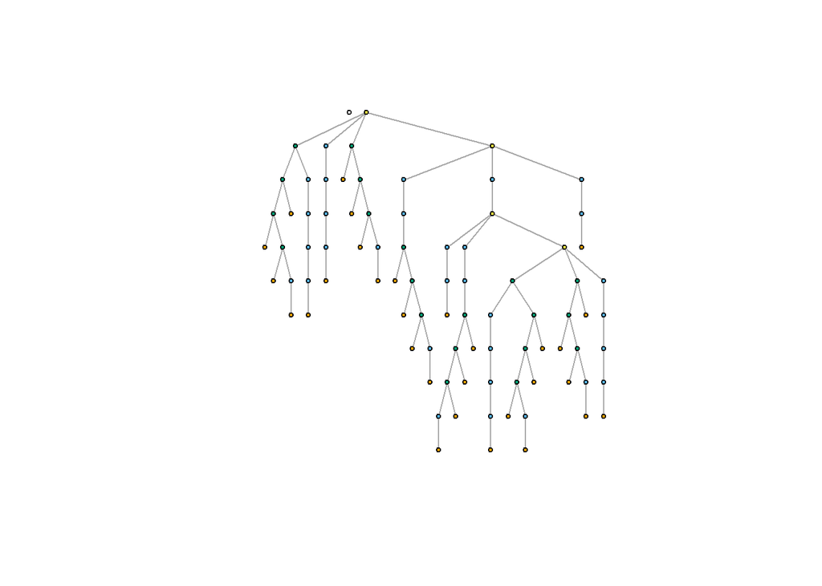

```r
Vox.list <- unique(rbind(my.rectVoxel(2),my.rectVoxel(2,c(1,1,1))))

#Vox.list <- my.double.voxel(Vox.list)

quad <- my.vox2quad(Vox.list)
rootid <- 20
tr <- my.quad2tree(quad,rootid)
my.draw.surface.tree(tr)
deg <- degree(tr$quad$g)
tr.g <- graph.edgelist(tr$tree.edges,directed=FALSE)
deg <- degree(tr.g) # 木のdegree
for(i in 1:length(tr$quad$nodes[,1])){
  # グラフ距離を適当倍して大雑把にカラースケールが現れるようにする
  d <- floor(tr$rootdist[i] * 0.3) +1
  #d <- deg[i]+1
  if(i == rootid){
        spheres3d(tr$quad$nodes[i,],col=1,radius=0.5)
    }else{
        spheres3d(tr$quad$nodes[i,],col=d,radius=0.05*d)
    }
  #print(d)
  #spheres3d(tr$quad$nodes[i,],col=d,radius=0.05*d)
}
spheres3d(tr$quad$nodes[46,],col=1,radius=0.3)

plot(tr.g,vertex.color=deg,layout=layout_as_tree,vertex.size=3,vertex.label="")
```

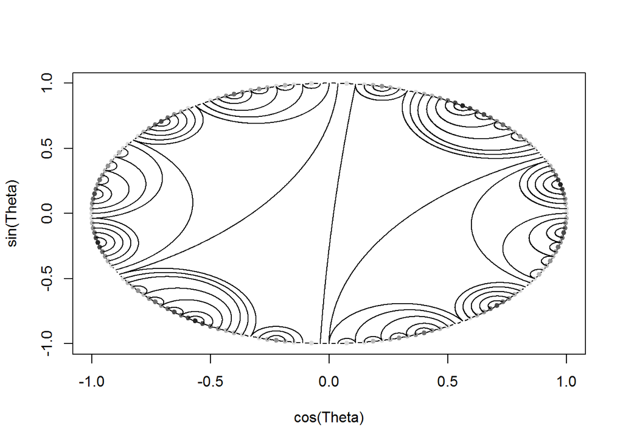

```r
e.st <- my.contour(tr)
#cirq <- my.cirq(tr$contour.nodes[,1])
my.cirq.plot(tr)
```

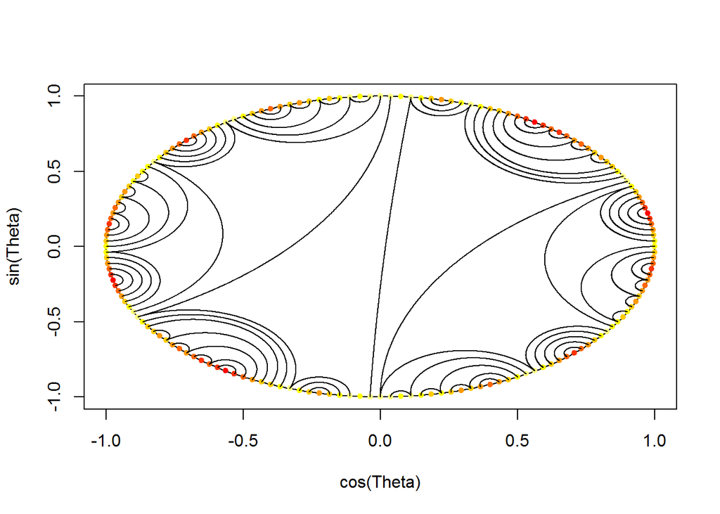

```r
my.cirq.plot(tr,gray=FALSE)
```

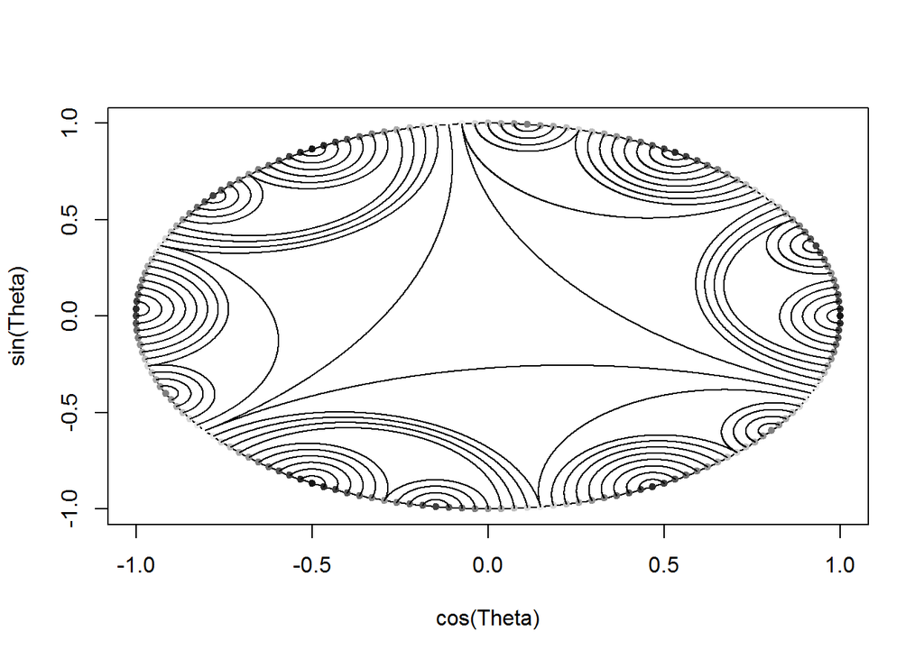

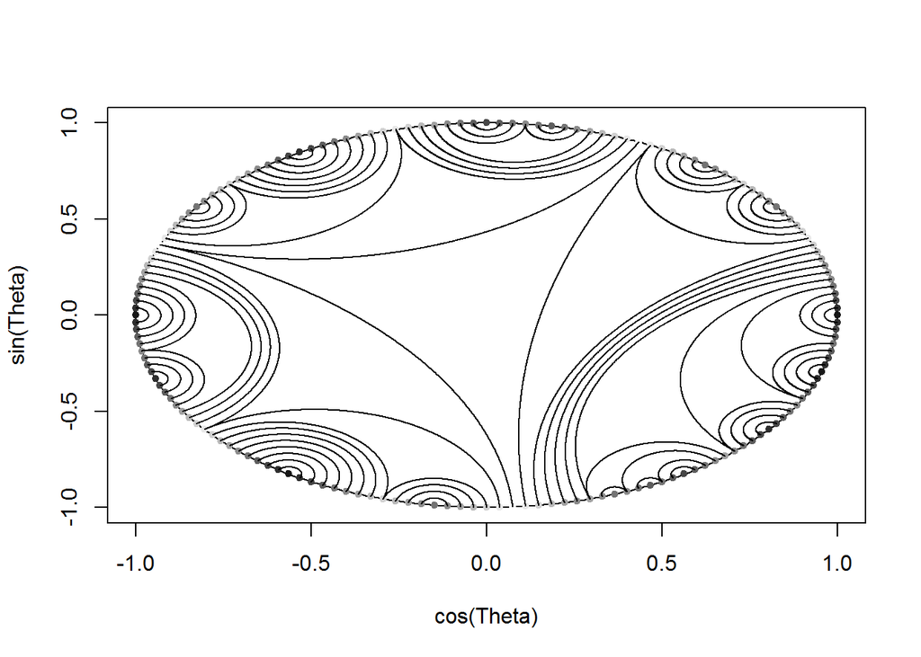

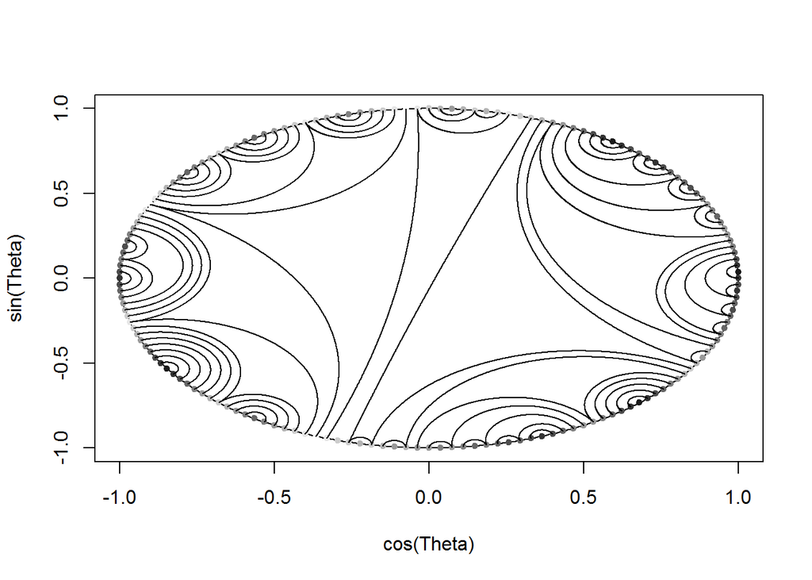

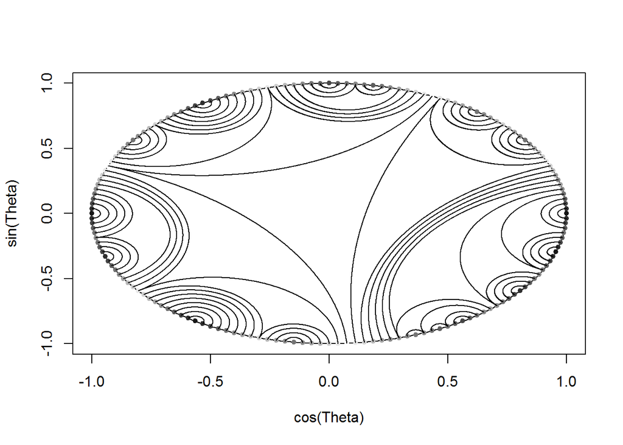

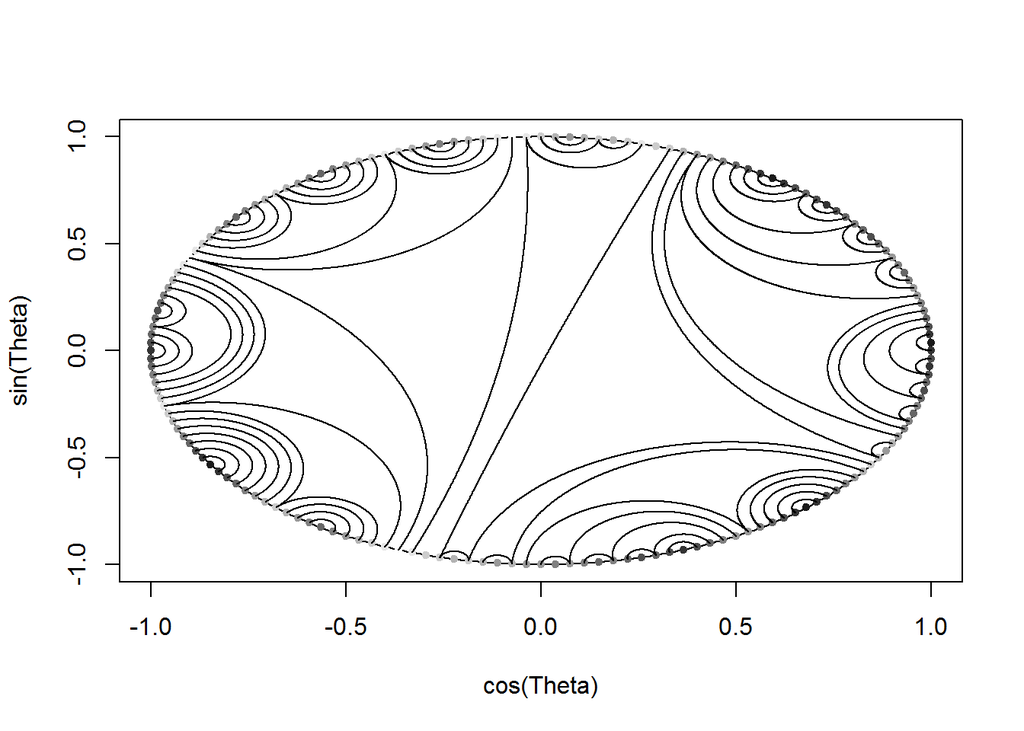

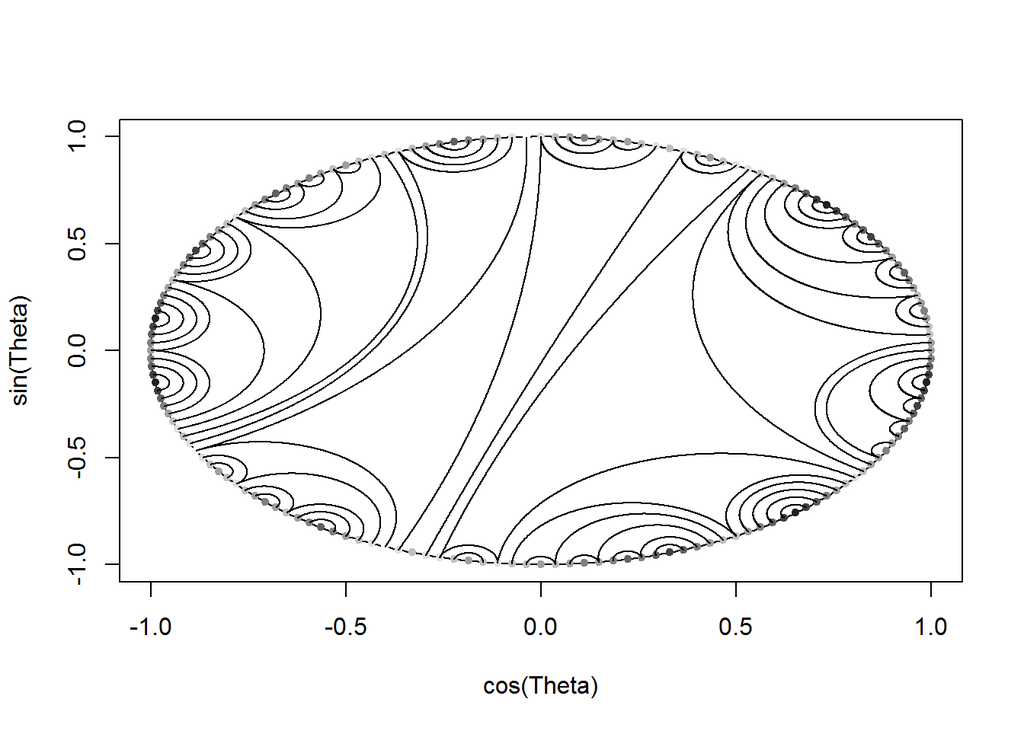

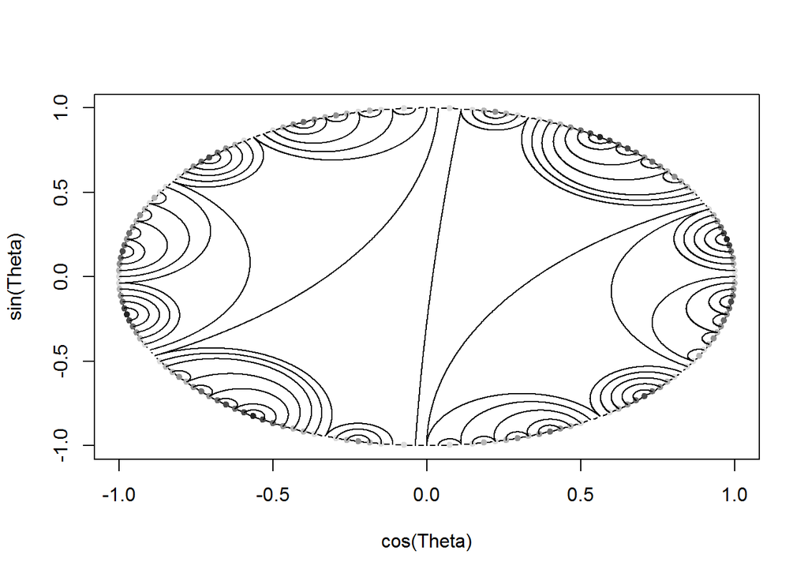

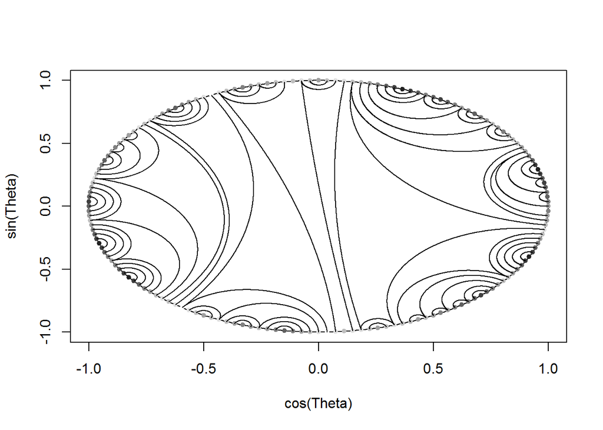

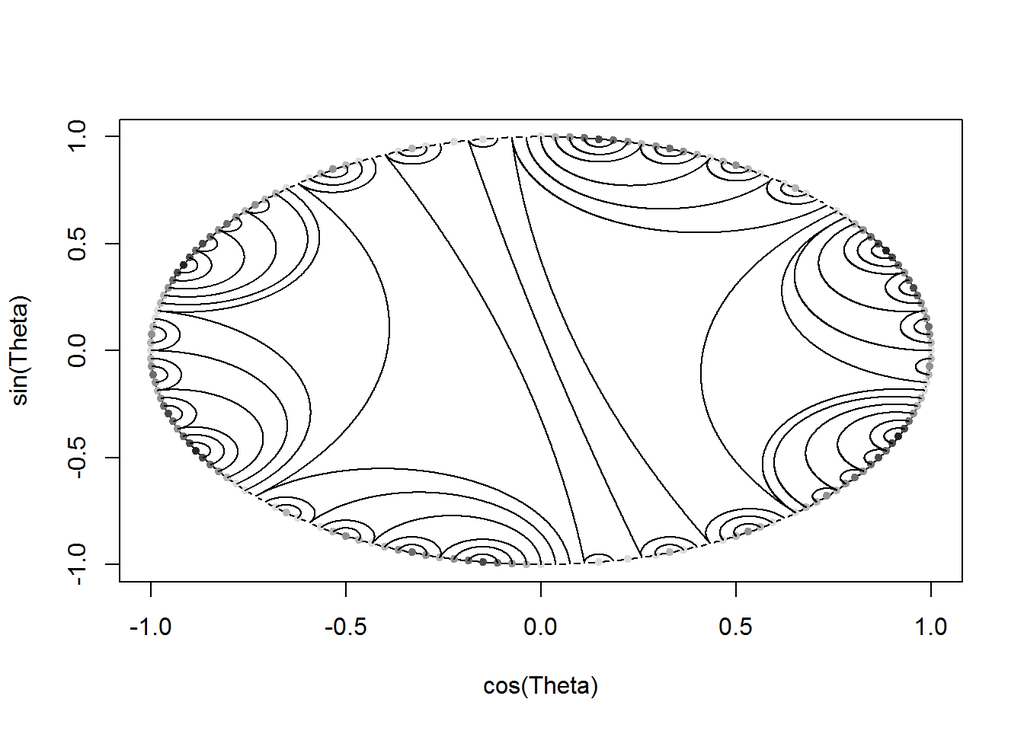

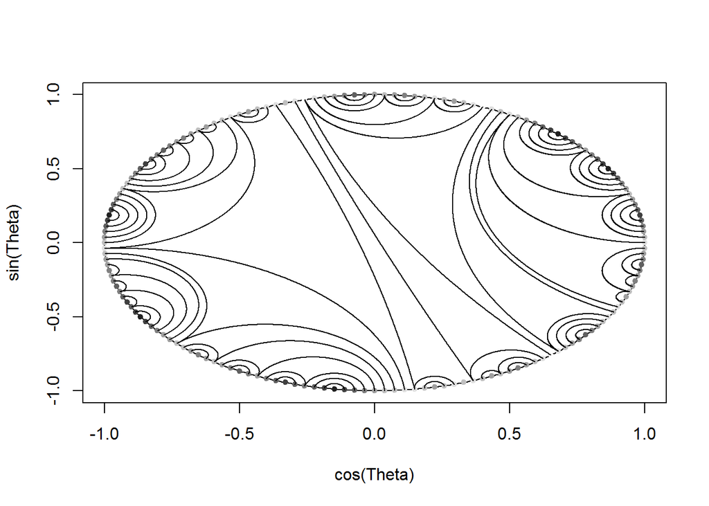

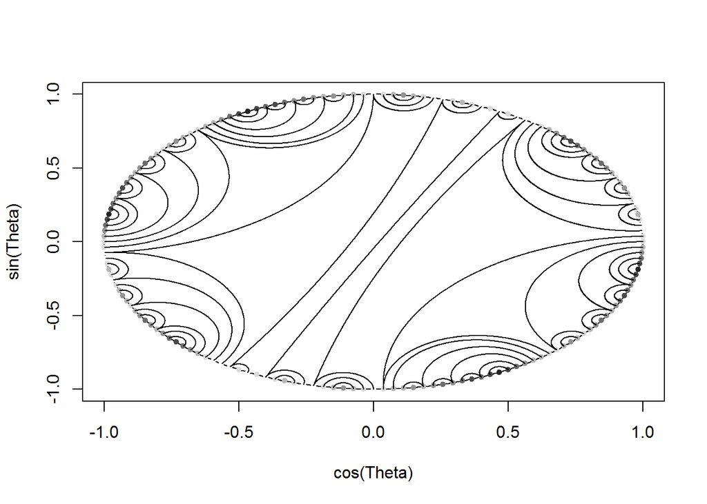

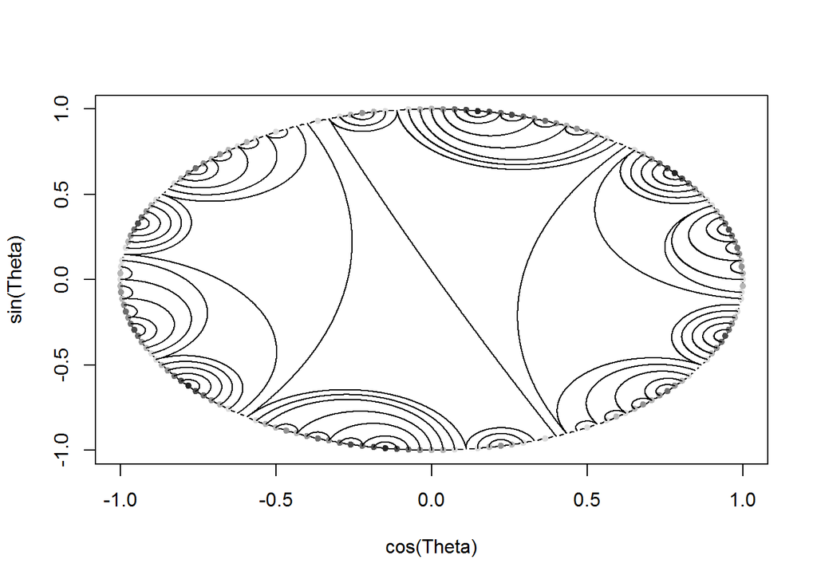

[42 more figures not shown]

```r
for(i in 1:length(tr$quad$nodes[,1])){
  rootid <- i
  tr <- my.quad2tree(quad,rootid)
  my.cirq.plot(tr)
}
```